# Assignment 3: Verify the Claim

- Show All Code
- Hide All Code
- View Source

Analyzing ACS data with R

Author

Nathan Leroy

Published

September 25, 2026

This analysis attempts to measure the accuracy of a 2018 article by the Philadelphia Media Network, “[New Census figures on Philly neighborhoods show inequality, high numbers of whites living in poverty](https://whyy.org/articles/new-census-figures-on-philly-neighborhoods-show-inequality-high-numbers-of-whites-living-in-poverty/)”. This article uses American Community Survey (ACS) data to conduct a neighborhood-by-neighborhood analysis of poverty and demographic conditions across Philadelphia.

According to the article, conditions in Philadelphia have gotten increasingly worse over the last 2 decades, with the following examples as proof:

- Poverty rates in the neighborhood of Eastwick increased from 12 to 26 percent between the 2006-10 census and the 2013-17 census.
- The median household income of Tioga-Nicetown declined from $28,026 to $17,493.
- White poverty increased drastically throughout the city, with the neighborhood of Holmesburg showing an over 900 percent increase (2% to 19%).
- The neighborhood of Fairhill had a poverty rate of 61 percent, and its median income dropped by $300.
- Visualizations of changes in poverty rates in Philadelphia show a significant increase in many of the poorer areas of the city.

The purpose of this analysis is to verify some of the claims made in the article by reconstructing the analysis of the ACS data and testing if the reported changes in the article are statistically significant.

## Part 1: Import Data & Create Tables

First, we install all required packages. An API key from the US Census Bureau is required for this project, and it needs to be installed before any data can be fetched. A key can be easily obtained [here](https://api.census.gov/data/key_signup.html).

```r
# Install required packages

library(tidycensus)
library(tidyverse)
```

After installing all the packages and confirming the API key is set up, we can start importing data from the ACS table.

For this analysis, we will use the following codes:

- B17001_001: total population of an area for which poverty can be determined.
- B17001_002: total number of people in that area who fall below the poverty line.

```r
# Variables from ACS table: total in poverty and total below
poverty_vars <- c(
  total_poverty = "B17001_001",
  below_poverty = "B17001_002"
)
```

```r
# 2013–2017 ACS 5-year estimates

#| message: false
#| warning: false

poverty_2013_2017 <- get_acs(
  geography = "tract",
  variables = poverty_vars,
  state = "PA",
  county = "Philadelphia",
  year = 2017,
  survey = "acs5",
  output = "wide",
  moe_level = 90
)

poverty_2013_2017 <- poverty_2013_2017 %>%
  mutate(
    period = "2013–2017",
    poverty_rate = (below_povertyE / total_povertyE) * 100
  )
```

```r
# 2006–2010 ACS 5-year estimates

#| message: false
#| warning: false

poverty_2006_2010 <- get_acs(
  geography = "tract",
  variables = poverty_vars,
  state = "PA",
  county = "Philadelphia",
  year = 2010,
  survey = "acs5",
  output = "wide",
  moe_level = 90
)

poverty_2006_2010 <- poverty_2006_2010 %>%
  mutate(
    period = "2006–2010",
    poverty_rate = (below_povertyE / total_povertyE) * 100
  )
```

Here, we combine the data from each census into a single table for easier analysis.

```r
poverty_both <- bind_rows(
  poverty_2006_2010,
  poverty_2013_2017
) %>%
  select(
    GEOID,
    NAME,
    period,
    total_povertyE,
    total_povertyM,
    below_povertyE,
    below_povertyM,
    poverty_rate
  ) %>%
  arrange(GEOID, period)

poverty_both
```

```
# A tibble: 768 × 8
   GEOID       NAME          period total_povertyE total_povertyM below_povertyE
   <chr>       <chr>         <chr>           <dbl>          <dbl>          <dbl>
 1 42101000100 Census Tract… 2006–…           3042            455            364
 2 42101000100 Census Tract… 2013–…           4155            429            292
 3 42101000200 Census Tract… 2006–…           1919            270            138
 4 42101000200 Census Tract… 2013–…           2558            425            962
 5 42101000300 Census Tract… 2006–…           2915            315            271
 6 42101000300 Census Tract… 2013–…           3315            311            280
 7 42101000401 Census Tract… 2006–…           1525            277            529
 8 42101000401 Census Tract… 2013–…           2632            287            486
 9 42101000402 Census Tract… 2006–…           3156            302            263
10 42101000402 Census Tract… 2013–…           3299            419            141
# ℹ 758 more rows
# ℹ 2 more variables: below_povertyM <dbl>, poverty_rate <dbl>
```

```r
poverty_change <- poverty_both %>%
  select(GEOID, NAME, period, poverty_rate) %>%
  pivot_wider(
    names_from = period,
    values_from = poverty_rate
  ) %>%
  mutate(
    change_percentage_points = `2013–2017` - `2006–2010`
  ) %>%
  arrange(desc(change_percentage_points))

# View the tracts with the largest increases
poverty_change %>%
  select(
    GEOID,
    NAME,
    `2006–2010`,
    `2013–2017`,
    change_percentage_points
  ) %>%
  print(n = 20)
```

```
# A tibble: 384 × 5
   GEOID       NAME               `2006–2010` `2013–2017` change_percentage_po…¹
   <chr>       <chr>                    <dbl>       <dbl>                  <dbl>
 1 42101005600 Census Tract 56, …       13.1         48.8                   35.7
 2 42101006000 Census Tract 60, …        4.05        34.9                   30.9
 3 42101000200 Census Tract 2, P…        7.19        37.6                   30.4
 4 42101020000 Census Tract 200,…       30.6         58.5                   27.9
 5 42101030502 Census Tract 305.…        5.31        31.5                   26.2
 6 42101989100 Census Tract 9891…       69.1         92.5                   23.3
 7 42101038900 Census Tract 389,…       13.4         35.3                   21.8
 8 42101016701 Census Tract 167.…       27.6         48.3                   20.7
 9 42101024500 Census Tract 245,…       38.5         59.0                   20.4
10 42101029100 Census Tract 291,…       27.4         46.7                   19.3
11 42101020300 Census Tract 203,…       27.4         46.2                   18.8
12 42101011000 Census Tract 110,…       29.7         48.2                   18.4
13 42101010600 Census Tract 106,…       26.4         44.7                   18.3
14 42101017602 Census Tract 176.…       44.0         61.6                   17.6
15 42101029000 Census Tract 290,…       25.7         43.1                   17.4
16 42101015101 Census Tract 151.…       34.3         50.7                   16.4
17 42101024400 Census Tract 244,…       18.5         34.8                   16.4
18 42101030100 Census Tract 301,…       19.9         35.8                   15.9
19 42101008102 Census Tract 81.0…       19.1         34.7                   15.6
20 42101033000 Census Tract 330,…       16.4         31.6                   15.2
# ℹ 364 more rows
# ℹ abbreviated name: ¹change_percentage_points
```

## Part 2: Testing

In this portion of our analysis, we want to determine how reliable our data for each census tract is. First, we calculate the MOE of the poverty rate for each census.

```r
# Calculate poverty rate and its MOE

# 2006-2010
poverty_2006_2010 <- poverty_2006_2010 %>%
  mutate(
    poverty_rate = below_povertyE / total_povertyE,

    poverty_rate_moe = moe_prop(
      num = below_povertyE,
      denom = total_povertyE,
      moe_num = below_povertyM,
      moe_denom = total_povertyM
    )
  )

# 2013-2017
poverty_2013_2017 <- poverty_2013_2017 %>%
  mutate(
    poverty_rate = below_povertyE / total_povertyE,

    poverty_rate_moe = moe_prop(
      num = below_povertyE,
      denom = total_povertyE,
      moe_num = below_povertyM,
      moe_denom = total_povertyM
    )
  )
```

We also want to calculate the coefficient of variation. We can do this using the two formulas below:

$$SE = \frac{\text{MOE}}{1.645}$$
And:
$$CV = \frac{\text{SE}}{estimate} * 100$$

We use the thresholds determined by Jurjevich et al. (2018) for this analysis:

- CV < 12% is reliable
- CV > 12% and CV < 40% is somewhat reliable
- CV > 40% is unreliable

```r
# CV Calculations

poverty_2006_2010 <- poverty_2006_2010 %>%
  mutate(
    poverty_rate_se = poverty_rate_moe / 1.645,
    poverty_rate_cv = (poverty_rate_se / poverty_rate) * 100,

    reliability = case_when(
      poverty_rate_cv < 12 ~ "Reliable",
      poverty_rate_cv <= 40 ~ "Somewhat reliable",
      poverty_rate_cv > 40 ~ "Unreliable",
      TRUE ~ NA_character_
    )
  )

poverty_2013_2017 <- poverty_2013_2017 %>%
  mutate(
    poverty_rate_se = poverty_rate_moe / 1.645,
    poverty_rate_cv = (poverty_rate_se / poverty_rate) * 100,

    reliability = case_when(
      poverty_rate_cv < 12 ~ "Reliable",
      poverty_rate_cv <= 40 ~ "Somewhat reliable",
      poverty_rate_cv > 40 ~ "Unreliable",
      TRUE ~ NA_character_
    )
  )
```

After these calculations, we join the two periods together to create one dataset with one row per tract using an inner join.

**Tip**

We use an inner join because we want tracts that have data in both periods for the change calculation.

```r
poverty_change <- poverty_2006_2010 %>%
  select(
    GEOID,
    NAME,
    poverty_rate_2006_2010 = poverty_rate,
    poverty_moe_2006_2010 = poverty_rate_moe,
    poverty_cv_2006_2010 = poverty_rate_cv,
    reliability_2006_2010 = reliability
  ) %>%
  inner_join(
    poverty_2013_2017 %>%
      select(
        GEOID,
        poverty_rate_2013_2017 = poverty_rate,
        poverty_moe_2013_2017 = poverty_rate_moe,
        poverty_cv_2013_2017 = poverty_rate_cv,
        reliability_2013_2017 = reliability
      ),
    by = "GEOID"
  )
```

Finally, we calculate the change in poverty rates by simply subtracting the 2006-10 rate from the newer 2013-17 rate.

```r
poverty_change <- poverty_change %>%
  mutate(
    change = poverty_rate_2013_2017 - poverty_rate_2006_2010
  )

# To make it easier to read, convert proportions into percents

poverty_change <- poverty_change %>%
  mutate(
    change_percentage_points = change * 100
  )
```

To calculate the MOE of the change between the two periods, we can use this formula:

$$\text{MOE}_{\text{change}} = \sqrt{\text{MOE}_1^2 + \text{MOE}_2^2}$$

```r
poverty_change <- poverty_change %>% mutate(
  change_moe = sqrt( poverty_moe_2006_2010^2 + poverty_moe_2013_2017^2 ) )
```

```r
poverty_change <- poverty_change %>%
  mutate(
    change_lower = change - change_moe,
    change_upper = change + change_moe
  )
```

Now, we can check if the change is statistically significant at the 90% confidence interval. If the change is larger than the MOE we calculated earlier, the it is considered to be statistically significant.

```r
poverty_change <- poverty_change %>%
  mutate(
    change_significant = abs(change) > change_moe
  )
```

Several census tracts have missing or incomplete values. We can run the script below to identify all of these tracts before deciding what to do with them.

```r
poverty_change %>%
  filter(
    is.na(poverty_rate_2006_2010) |
      is.na(poverty_rate_2013_2017) |
      is.na(change)
  ) %>%
  select(
    GEOID,
    NAME,
    poverty_rate_2006_2010,
    poverty_rate_2013_2017,
    change
  )
```

```
# A tibble: 8 × 5
  GEOID       NAME          poverty_rate_2006_2010 poverty_rate_2013_2017 change
  <chr>       <chr>                          <dbl>                  <dbl>  <dbl>
1 42101005000 Census Tract…               NaN                         NaN    NaN
2 42101980300 Census Tract…               NaN                         NaN    NaN
3 42101980400 Census Tract…               NaN                         NaN    NaN
4 42101980500 Census Tract…               NaN                         NaN    NaN
5 42101980600 Census Tract…                 0.0978                    NaN    NaN
6 42101980700 Census Tract…               NaN                         NaN    NaN
7 42101980800 Census Tract…               NaN                         NaN    NaN
8 42101980900 Census Tract…               NaN                         NaN    NaN
```

For this analysis, we will drop any incomplete rows, as the poverty level cannot be accurately calculated.

```r
poverty_analysis <- poverty_change %>%
  filter(
    !is.na(change),
    !is.na(change_moe),
    !is.na(change_significant)
  )
```

```r
poverty_analysis %>%
  summarise(
    detectable_change = sum(change_significant),
    no_detectable_change = sum(!change_significant),
    total_tracts = n(),
    percent_detectable = mean(change_significant) * 100,
    percent_not_detectable = mean(!change_significant) * 100
  )
```

```
# A tibble: 1 × 5
  detectable_change no_detectable_change total_tracts percent_detectable
              <int>                <int>        <int>              <dbl>
1                63                  313          376               16.8
# ℹ 1 more variable: percent_not_detectable <dbl>
```

This table displays all the calculated data associated with the tracts. The tracts with the greatest change in poverty level are displayed on top.

```r
poverty_analysis %>%
  select(
    GEOID,
    NAME,
    poverty_rate_2006_2010,
    poverty_moe_2006_2010,
    poverty_rate_2013_2017,
    poverty_moe_2013_2017,
    change_percentage_points,
    change_moe,
    reliability_2006_2010,
    reliability_2013_2017,
    change_significant
  ) %>%
  arrange(desc(abs(change_percentage_points)))
```

```
# A tibble: 376 × 11
   GEOID       NAME                 poverty_rate_2006_2010 poverty_moe_2006_2010
   <chr>       <chr>                                 <dbl>                 <dbl>
 1 42101980000 Census Tract 9800, …                 0.838                 0.224
 2 42101036400 Census Tract 364, P…                 0.912                 0.232
 3 42101005600 Census Tract 56, Ph…                 0.131                 0.0866
 4 42101002000 Census Tract 20, Ph…                 0.514                 0.260
 5 42101006000 Census Tract 60, Ph…                 0.0405                0.0179
 6 42101000200 Census Tract 2, Phi…                 0.0719                0.0361
 7 42101012203 Census Tract 122.03…                 0.541                 0.232
 8 42101020000 Census Tract 200, P…                 0.306                 0.119
 9 42101030502 Census Tract 305.02…                 0.0531                0.0386
10 42101031102 Census Tract 311.02…                 0.370                 0.154
# ℹ 366 more rows
# ℹ 7 more variables: poverty_rate_2013_2017 <dbl>,
#   poverty_moe_2013_2017 <dbl>, change_percentage_points <dbl>,
#   change_moe <dbl>, reliability_2006_2010 <chr>, reliability_2013_2017 <chr>,
#   change_significant <lgl>
```

## Part 3: Results and Visualizations

### Map

We haven’t imported the geometry of the tracts yet, so we need to run the following code block:

```r
#| include: false

library(sf)

invisible(capture.output(
  tracts <- get_acs(
    geography = "tract",
    variables = "B01003_001",
    state = "PA",
    county = "Philadelphia",
    year = 2017,
    survey = "acs5",
    geometry = TRUE
  )
))
```

Next, we join it to the main table.

```r
poverty_map <- tracts %>%
  select(GEOID, geometry) %>%
  left_join(
    poverty_analysis,
    by = "GEOID"
  )
```

Finally, we display the map.

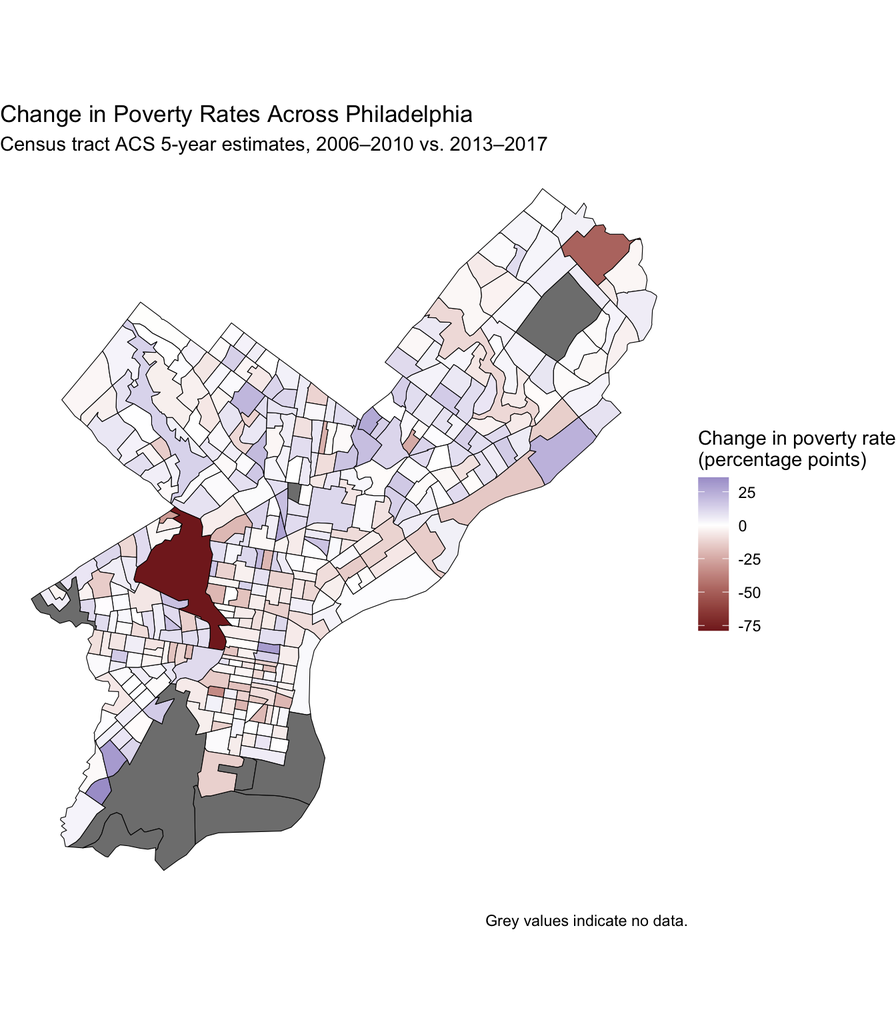

```r
poverty_map %>%
mutate(
  change_percentage_points = change * 100
) %>%
  ggplot() +
  geom_sf(
    aes(fill = change_percentage_points),
    color = "black"
  ) +
  scale_fill_gradient2(
    name = "Change in poverty rate\n(percentage points)"
  ) +
  theme_void() +
  labs(
    title = "Change in Poverty Rates Across Philadelphia",
    subtitle = "Census tract ACS 5-year estimates, 2006–2010 vs. 2013–2017",
    caption = "Grey values indicate no data."
  )
```

This map displays where there is a statistically significant change in poverty levels between the two censuses.

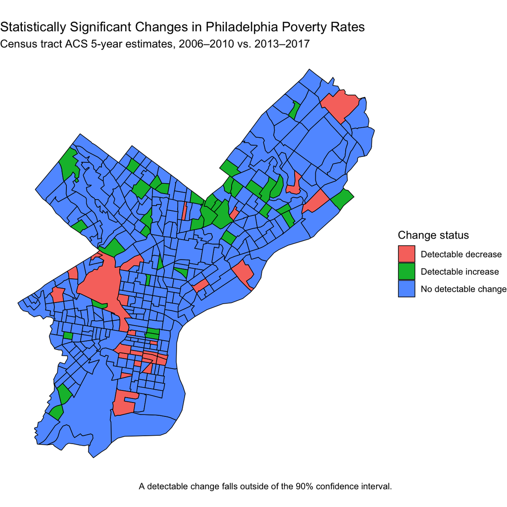

```r
poverty_map %>%
  mutate(
    change_status = case_when(
      change_significant & change > 0 ~ "Detectable increase",
      change_significant & change < 0 ~ "Detectable decrease",
      TRUE ~ "No detectable change"
    )
  ) %>%
  ggplot() +
  geom_sf(
    aes(fill = change_status),
    color = "black",
    linewidth = 0.3
  ) +
  theme_void() +
  labs(
    title = "Statistically Significant Changes in Philadelphia Poverty Rates",
    subtitle = "Census tract ACS 5-year estimates, 2006–2010 vs. 2013–2017",
    fill = "Change status",
    caption = "A detectable change falls outside of the 90% confidence interval."
  )
```

### Errorbar Visualization

This visualization shows only the statistically significant changes in poverty rates between the two time periods. The bars represent the estimated change, while the error bars (thinner black bars) represent the 90% margin of error.

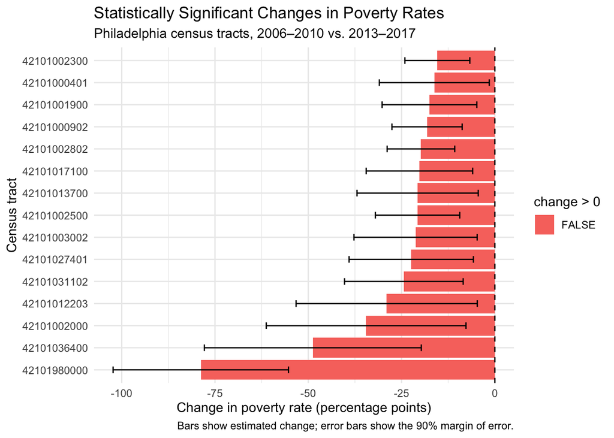

```r
poverty_analysis %>%
  filter(change_significant) %>%
  arrange(change) %>%
  slice_head(n = 15) %>%
  ggplot(aes(x = reorder(GEOID, change), y = change * 100)) +
  geom_col(aes(fill = change > 0)) +
  geom_errorbar(
    aes(
      ymin = (change - change_moe) * 100,
      ymax = (change + change_moe) * 100
    ),
    width = 0.3
  ) +
  geom_hline(yintercept = 0, linetype = "dashed") +
  coord_flip() +
  theme_minimal() +
  labs(
    title = "Statistically Significant Changes in Poverty Rates",
    subtitle = "Philadelphia census tracts, 2006–2010 vs. 2013–2017",
    x = "Census tract",
    y = "Change in poverty rate (percentage points)",
    caption = "Bars show estimated change; error bars show the 90% margin of error."
  )
```

### Reliability Table

This table displays the reliability of census tract poverty estimates based on their CV. Lower CV values indicate more reliable estimates.

**Reliability table**

```r
library(gt)

reliability_table <- poverty_analysis %>%
  mutate(
    cv = pmax(
      poverty_cv_2006_2010,
      poverty_cv_2013_2017,
      na.rm = TRUE
    ),
    dot = case_when(
      cv < 12 ~ "🟢",
      cv <= 40 ~ "🟡",
      TRUE ~ "🔴"
    ),
    flag = case_when(
      cv < 12 ~ "Reliable",
      cv <= 40 ~ "Somewhat reliable",
      TRUE ~ "Unreliable"
    )
  ) %>%
  arrange(desc(cv)) %>%
  select(
    dot,
    GEOID,
    poverty_cv_2006_2010,
    poverty_cv_2013_2017,
    flag
  )

reliability_table %>%
  gt() %>%
  fmt_number(
    columns = c(poverty_cv_2006_2010, poverty_cv_2013_2017),

  ) %>%
  cols_label(
    dot = "",
    GEOID = "Census tract",
    poverty_cv_2006_2010 = "CV (%)\n2006–2010",
    poverty_cv_2013_2017 = "CV (%)\n2013–2017",
    flag = "Reliability"
  ) %>%
  cols_align( align = "center", columns = dot
  ) %>%
  tab_header(
    title = "Reliability of Philadelphia Census Tract Poverty Estimates",
    subtitle = "ACS 5-year estimates, 2006–2010 and 2013–2017"
  ) %>%
  tab_source_note(
    "Reliability thresholds follow Jurjevich et al. (2018): CV < 12% reliable, 12–40% somewhat reliable, > 40% unreliable."
  )
```

Reliability of Philadelphia Census Tract Poverty Estimates

ACS 5-year estimates, 2006–2010 and 2013–2017

|  | Census tract | CV (%) 2006–2010 | CV (%) 2013–2017 | Reliability |
| --- | --- | --- | --- | --- |
| 🔴 | 42101023100 | Inf | 66.70 | Unreliable |
| 🔴 | 42101980100 | Inf | 61.54 | Unreliable |
| 🔴 | 42101989100 | 18.20 | 144.89 | Unreliable |
| 🔴 | 42101980000 | 16.29 | 85.64 | Unreliable |
| 🔴 | 42101023500 | 71.58 | 40.05 | Unreliable |
| 🔴 | 42101023600 | 70.84 | 41.10 | Unreliable |
| 🔴 | 42101001001 | 70.38 | 39.92 | Unreliable |
| 🔴 | 42101036600 | 68.06 | 40.61 | Unreliable |
| 🔴 | 42101034801 | 66.38 | 28.97 | Unreliable |
| 🔴 | 42101025600 | 33.71 | 64.68 | Unreliable |
| 🔴 | 42101980200 | 63.24 | 51.39 | Unreliable |
| 🔴 | 42101001500 | 62.02 | 26.00 | Unreliable |
| 🔴 | 42101038500 | 59.56 | 39.23 | Unreliable |
| 🔴 | 42101038600 | 54.85 | 59.26 | Unreliable |
| 🔴 | 42101038700 | 55.11 | 33.19 | Unreliable |
| 🔴 | 42101022000 | 54.96 | 45.41 | Unreliable |
| 🔴 | 42101033702 | 54.38 | 24.15 | Unreliable |
| 🔴 | 42101038400 | 54.08 | 26.57 | Unreliable |
| 🔴 | 42101001002 | 53.88 | 46.70 | Unreliable |
| 🔴 | 42101014300 | 52.67 | 29.87 | Unreliable |
| 🔴 | 42101025800 | 52.36 | 27.11 | Unreliable |
| 🔴 | 42101036502 | 51.44 | 40.04 | Unreliable |
| 🔴 | 42101034200 | 50.93 | 31.31 | Unreliable |
| 🔴 | 42101035602 | 50.55 | 40.30 | Unreliable |
| 🔴 | 42101006100 | 49.20 | 23.10 | Unreliable |
| 🔴 | 42101033900 | 49.14 | 31.56 | Unreliable |
| 🔴 | 42101002702 | 48.32 | 33.94 | Unreliable |
| 🔴 | 42101034000 | 40.81 | 47.92 | Unreliable |
| 🔴 | 42101013601 | 47.34 | 36.65 | Unreliable |
| 🔴 | 42101034702 | 39.17 | 47.08 | Unreliable |

[output cut: 346 more lines]

Reliability thresholds follow Jurjevich et al. (2018): CV < 12% reliable, 12–40% somewhat reliable, > 40% unreliable.

## Part 4: Adjudication of Claims

A challenge of this project is that the census tracts found in the ACS dataset do not correspond to traditional boundaries of Philadelphia neighborhoods, which are somewhat informal and not collected or defined by the city for official use. Therefore, we have to estimate which tracts fall into the neighborhoods the article is analyzing. This process is naturally a source of error in this project.

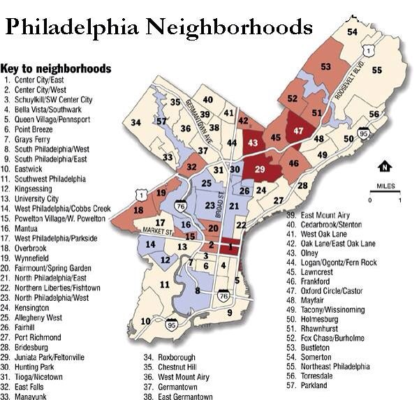

## Part 5: Conclusion

Therefore, this analysis provides mixed evidence for the article’s claims. Changes in poverty were not uniform across Philadelphia, and some areas in close proximity to each other experienced significant increases in poverty while some experienced significant decreases. Many other areas experienced no statistically significant changes at all. The data in many of these census tracts was deemed either “somewhat reliable” or “unreliable” based on its MOE, and a more detailed and complete survey of this area is necessary to get fully accurate results. Additionally, it would improve the accuracy of this analysis to conduct the survey by neighborhood instead of by census tract; however, it would be quite logistically challenging.